# APG analysis

##### Novel X Trials

###### Condition Effect

```r
m <- lm(dprime~conditionC,data=subset(subj_testType,exp=="exp3"&testType=="novelX"))
summary(m)
```

```
##
## Call:
## lm(formula = dprime ~ conditionC, data = subset(subj_testType,
##     exp == "exp3" & testType == "novelX"))
##
## Residuals:
##     Min      1Q  Median      3Q     Max
## -2.1854 -0.6917 -0.2001  0.3704  2.9863
##
## Coefficients:
##             Estimate Std. Error t value Pr(>|t|)
## (Intercept)  0.44589    0.08133   5.483 1.43e-07 ***
## conditionC   0.49162    0.16265   3.023  0.00288 **
## ---
## Signif. codes:  0 '***' 0.001 '**' 0.01 '*' 0.05 '.' 0.1 ' ' 1
##
## Residual standard error: 1.088 on 177 degrees of freedom
## Multiple R-squared:  0.04908,    Adjusted R-squared:  0.04371
## F-statistic: 9.136 on 1 and 177 DF,  p-value: 0.002879
```

###### Testing against chance: Learnable Pre-Exposure

```r
m <- lm(dprime~1,data=subset(subj_testType,exp=="exp3"&testType=="novelX"&conditionC==0.5))
summary(m)
```

```
##
## Call:
## lm(formula = dprime ~ 1, data = subset(subj_testType, exp ==
##     "exp3" & testType == "novelX" & conditionC == 0.5))
##
## Residuals:
##     Min      1Q  Median      3Q     Max
## -2.0520 -0.9798 -0.5520  0.5037  2.4947
##
## Coefficients:
##             Estimate Std. Error t value Pr(>|t|)
## (Intercept)   0.6917     0.1375   5.032 2.51e-06 ***
## ---
## Signif. codes:  0 '***' 0.001 '**' 0.01 '*' 0.05 '.' 0.1 ' ' 1
##
## Residual standard error: 1.304 on 89 degrees of freedom
```

###### Testing against chance: Unstructured Pre-Exposure

```r
m <- lm(dprime~1,data=subset(subj_testType,exp=="exp3"&testType=="novelX"&conditionC==-0.5))
summary(m)
```

```
##
## Call:
## lm(formula = dprime ~ 1, data = subset(subj_testType, exp ==
##     "exp3" & testType == "novelX" & conditionC == -0.5))
##
## Residuals:
##     Min      1Q  Median      3Q     Max
## -2.1854 -0.4911 -0.2001  0.2559  2.9863
##
## Coefficients:
##             Estimate Std. Error t value Pr(>|t|)
## (Intercept)   0.2001     0.0862   2.321   0.0226 *
## ---
## Signif. codes:  0 '***' 0.001 '**' 0.01 '*' 0.05 '.' 0.1 ' ' 1
##
## Residual standard error: 0.8132 on 88 degrees of freedom
```

##### Interaction between Novel X and Familiar X trials

```r
#recode test type
subj_testType$testTypeC <- ifelse(subj_testType$testType=="novelX",0.5,
                    ifelse(subj_testType$testType=="familiarX",-0.5,NA))
m <- lm(dprime~conditionC*testTypeC,data=subset(subj_testType,exp=="exp3"))
summary(m)
```

```
##
## Call:
## lm(formula = dprime ~ conditionC * testTypeC, data = subset(subj_testType,
##     exp == "exp3"))
##
## Residuals:
##     Min      1Q  Median      3Q     Max
## -2.1854 -0.7360 -0.2001  0.3704  2.9863
##
## Coefficients:
##                       Estimate Std. Error t value Pr(>|t|)
## (Intercept)           0.466283   0.057513   8.107 8.54e-15 ***
## conditionC            0.495159   0.115027   4.305 2.17e-05 ***
## testTypeC            -0.040781   0.115027  -0.355    0.723
## conditionC:testTypeC -0.007077   0.230053  -0.031    0.975
## ---
## Signif. codes:  0 '***' 0.001 '**' 0.01 '*' 0.05 '.' 0.1 ' ' 1
##
## Residual standard error: 1.088 on 354 degrees of freedom
## Multiple R-squared:  0.05007,    Adjusted R-squared:  0.04202
## F-statistic: 6.219 on 3 and 354 DF,  p-value: 0.0003985
```

#### Response Bias

##### Overall

```r
#recode condition
subj_overall$conditionC <- ifelse(subj_overall$condition=="Learnable Pre-Exposure",0.5,
                    ifelse(subj_overall$condition=="Unstructured Pre-Exposure",-0.5,NA))
##all data
m <- lm(c~conditionC,data=subset(subj_overall,exp=="exp3"))
summary(m)
```

```
##
## Call:
## lm(formula = c ~ conditionC, data = subset(subj_overall, exp ==
##     "exp3"))
##
## Residuals:
##     Min      1Q  Median      3Q     Max
## -1.7673 -0.1365  0.0241  0.2215  0.9152
##
## Coefficients:
##             Estimate Std. Error t value Pr(>|t|)
## (Intercept) -0.15550    0.02925  -5.316 3.17e-07 ***
## conditionC   0.01662    0.05850   0.284    0.777
## ---
## Signif. codes:  0 '***' 0.001 '**' 0.01 '*' 0.05 '.' 0.1 ' ' 1
##
## Residual standard error: 0.3914 on 177 degrees of freedom
## Multiple R-squared:  0.0004559,  Adjusted R-squared:  -0.005191
## F-statistic: 0.08074 on 1 and 177 DF,  p-value: 0.7766
```

###### Testing against chance: Learnable Pre-Exposure

```r
m <- lm(c~1,data=subset(subj_overall,exp=="exp3"&conditionC==0.5))
summary(m)
```

```
##
## Call:
## lm(formula = c ~ 1, data = subset(subj_overall, exp == "exp3" &
##     conditionC == 0.5))
##
## Residuals:
##      Min       1Q   Median       3Q      Max
## -1.76732 -0.13803  0.07258  0.21705  0.74491
##
## Coefficients:
##             Estimate Std. Error t value Pr(>|t|)
## (Intercept) -0.14719    0.03944  -3.732 0.000334 ***
## ---
## Signif. codes:  0 '***' 0.001 '**' 0.01 '*' 0.05 '.' 0.1 ' ' 1
##
## Residual standard error: 0.3741 on 89 degrees of freedom
```

###### Testing against chance: Unstructured Pre-Exposure

```r
m <- lm(c~1,data=subset(subj_overall,exp=="exp3"&conditionC==-0.5))
summary(m)
```

```
##
## Call:
## lm(formula = c ~ 1, data = subset(subj_overall, exp == "exp3" &
##     conditionC == -0.5))
##
## Residuals:
##      Min       1Q   Median       3Q      Max
## -1.59005 -0.13091  0.02271  0.23507  0.91524
##
## Coefficients:
##             Estimate Std. Error t value Pr(>|t|)
## (Intercept) -0.16381    0.04325  -3.787 0.000278 ***
## ---
## Signif. codes:  0 '***' 0.001 '**' 0.01 '*' 0.05 '.' 0.1 ' ' 1
##
## Residual standard error: 0.4081 on 88 degrees of freedom
```

##### Familiar X Trials

###### Condition Effect

```r
#recode condition
subj_testType$conditionC <- ifelse(subj_testType$condition=="Learnable Pre-Exposure",0.5,
                    ifelse(subj_testType$condition=="Unstructured Pre-Exposure",-0.5,NA))

m <- lm(c~conditionC,data=subset(subj_testType,exp=="exp3"&testType=="familiarX"))
summary(m)
```

```
##
## Call:
## lm(formula = c ~ conditionC, data = subset(subj_testType, exp ==
##     "exp3" & testType == "familiarX"))
##
## Residuals:
##      Min       1Q   Median       3Q      Max
## -1.23566 -0.22471  0.07234  0.35756  0.78829
##
## Coefficients:
##             Estimate Std. Error t value Pr(>|t|)
## (Intercept) -0.40651    0.03476 -11.696   <2e-16 ***
## conditionC   0.09791    0.06951   1.409    0.161
## ---
## Signif. codes:  0 '***' 0.001 '**' 0.01 '*' 0.05 '.' 0.1 ' ' 1
##
## Residual standard error: 0.465 on 177 degrees of freedom
## Multiple R-squared:  0.01108,    Adjusted R-squared:  0.005498
## F-statistic: 1.984 on 1 and 177 DF,  p-value: 0.1607
```

###### Testing against chance: Learnable Pre-Exposure

```r
m <- lm(c~1,data=subset(subj_testType,exp=="exp3"&testType=="familiarX"&conditionC==0.5))
summary(m)
```

```
##
## Call:
## lm(formula = c ~ 1, data = subset(subj_testType, exp == "exp3" &
##     testType == "familiarX" & conditionC == 0.5))
##
## Residuals:
##      Min       1Q   Median       3Q      Max
## -1.23566 -0.19143  0.07234  0.35756  0.78829
##
## Coefficients:
##             Estimate Std. Error t value Pr(>|t|)
## (Intercept) -0.35756    0.04803  -7.444 5.92e-11 ***
## ---
## Signif. codes:  0 '***' 0.001 '**' 0.01 '*' 0.05 '.' 0.1 ' ' 1
##
## Residual standard error: 0.4557 on 89 degrees of freedom
```

###### Testing against chance: Unstructured Pre-Exposure

```r
m <- lm(c~1,data=subset(subj_testType,exp=="exp3"&testType=="familiarX"&conditionC==-0.5))
summary(m)
```

```
##
## Call:
## lm(formula = c ~ 1, data = subset(subj_testType, exp == "exp3" &
##     testType == "familiarX" & conditionC == -0.5))
##
## Residuals:
##     Min      1Q  Median      3Q     Max
## -1.1378 -0.2247  0.1430  0.3158  0.6834
##
## Coefficients:
##             Estimate Std. Error t value Pr(>|t|)
## (Intercept) -0.45547    0.05027  -9.061 3.07e-14 ***
## ---
## Signif. codes:  0 '***' 0.001 '**' 0.01 '*' 0.05 '.' 0.1 ' ' 1
##
## Residual standard error: 0.4742 on 88 degrees of freedom
```

##### Novel X Trials

###### Condition Effect

```r
m <- lm(c~conditionC,data=subset(subj_testType,exp=="exp3"&testType=="novelX"))
summary(m)
```

```
##
## Call:
## lm(formula = c ~ conditionC, data = subset(subj_testType, exp ==
##     "exp3" & testType == "novelX"))
##
## Residuals:
##      Min       1Q   Median       3Q      Max
## -1.65861 -0.29336 -0.06539  0.21983  1.52783
##
## Coefficients:
##             Estimate Std. Error t value Pr(>|t|)
## (Intercept)  0.09942    0.04583   2.169   0.0314 *
## conditionC  -0.06806    0.09167  -0.742   0.4588
## ---
## Signif. codes:  0 '***' 0.001 '**' 0.01 '*' 0.05 '.' 0.1 ' ' 1
##
## Residual standard error: 0.6132 on 177 degrees of freedom
## Multiple R-squared:  0.003105,   Adjusted R-squared:  -0.002527
## F-statistic: 0.5513 on 1 and 177 DF,  p-value: 0.4588
```

###### Testing against chance: Learnable Pre-Exposure

```r
m <- lm(c~1,data=subset(subj_testType,exp=="exp3"&testType=="novelX"&conditionC==0.5))
summary(m)
```

```
##
## Call:
## lm(formula = c ~ 1, data = subset(subj_testType, exp == "exp3" &
##     testType == "novelX" & conditionC == 0.5))
##
## Residuals:
##      Min       1Q   Median       3Q      Max
## -1.65861 -0.23238 -0.06539  0.21983  1.52783
##
## Coefficients:
##             Estimate Std. Error t value Pr(>|t|)
## (Intercept)  0.06539    0.05611   1.165    0.247
##
## Residual standard error: 0.5323 on 89 degrees of freedom
```

###### Testing against chance: Unstructured Pre-Exposure

```r
m <- lm(c~1,data=subset(subj_testType,exp=="exp3"&testType=="novelX"&conditionC==-0.5))
summary(m)
```

```
##
## Call:
## lm(formula = c ~ 1, data = subset(subj_testType, exp == "exp3" &
##     testType == "novelX" & conditionC == -0.5))
##
## Residuals:
##     Min      1Q  Median      3Q     Max
## -1.5404 -0.4187 -0.1335  0.1518  1.4598
##
## Coefficients:
##             Estimate Std. Error t value Pr(>|t|)
## (Intercept)  0.13345    0.07265   1.837   0.0696 .
## ---
## Signif. codes:  0 '***' 0.001 '**' 0.01 '*' 0.05 '.' 0.1 ' ' 1
##
## Residual standard error: 0.6854 on 88 degrees of freedom
```

##### Interaction between Novel X and Familiar X trials

```r
m <- lm(c~conditionC*testTypeC,data=subset(subj_testType,exp=="exp3"))
summary(m)
```

```
##
## Call:
## lm(formula = c ~ conditionC * testTypeC, data = subset(subj_testType,
##     exp == "exp3"))
##
## Residuals:
##      Min       1Q   Median       3Q      Max
## -1.65861 -0.27316  0.00626  0.31431  1.52783
##
## Coefficients:
##                      Estimate Std. Error t value Pr(>|t|)
## (Intercept)          -0.15355    0.02876  -5.339 1.68e-07 ***
## conditionC            0.01492    0.05752   0.259    0.795
## testTypeC             0.50594    0.05752   8.796  < 2e-16 ***
## conditionC:testTypeC -0.16597    0.11504  -1.443    0.150
## ---
## Signif. codes:  0 '***' 0.001 '**' 0.01 '*' 0.05 '.' 0.1 ' ' 1
##
## Residual standard error: 0.5442 on 354 degrees of freedom
## Multiple R-squared:  0.1832, Adjusted R-squared:  0.1762
## F-statistic: 26.46 on 3 and 354 DF,  p-value: 1.833e-15
```

Much larger response bias for familiar X trials compared to novel X trials.

## Overall Analysis: Experiments 1 - 3

### Plot all data from all conditions across Experiments 1 - 3

#### Plot

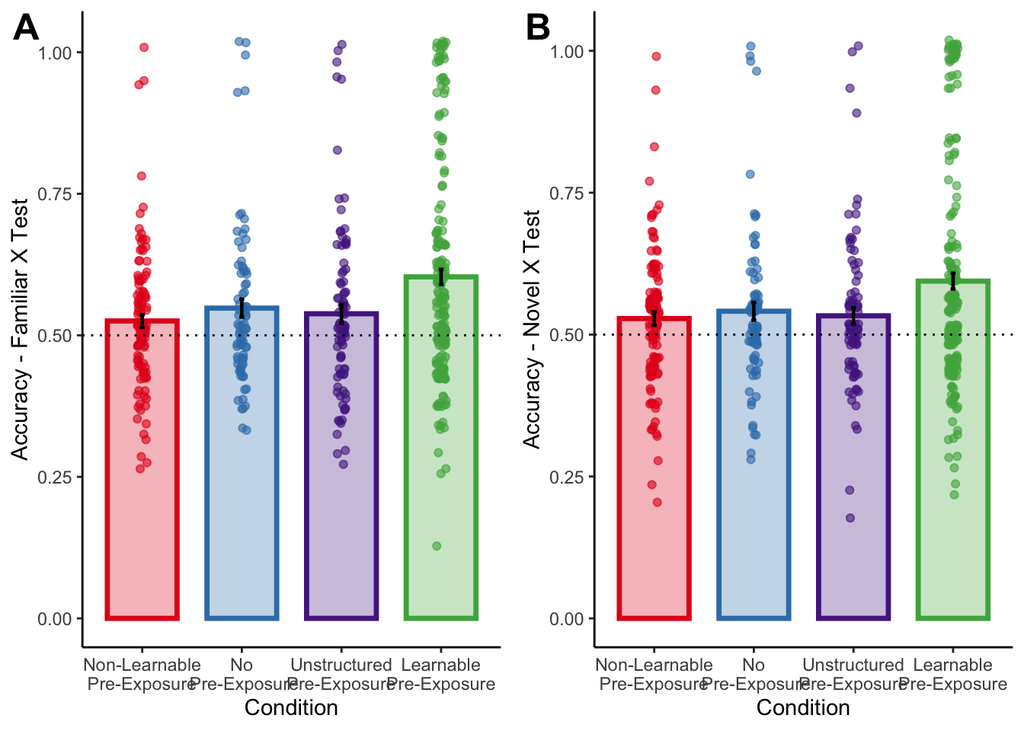

```r
#Familiar X test
p1 <- ggplot(subset(test_type,testType=="familiarX"),aes(condition,accuracy,fill=condition, color=condition))+
  geom_bar(position=position_dodge(.9), stat="identity", size=1.2,alpha=0.3, width=0.7)+
  geom_jitter(data=subset(subj_testType,testType=="familiarX"),aes(y=acc), width = 0.05, alpha=0.6,shape=21)+
  geom_errorbar(aes(ymin=accuracy-se,ymax=accuracy+se),color="black",position=position_dodge(.9),width=0.05, height=0.02, size=0.8)+
  theme_classic(base_size=11)+
  geom_hline(yintercept=0.5, linetype="dotted")+
  scale_x_discrete(name="Condition",
                   breaks=c("Non-Learnable Pre-Exposure","No Pre-Exposure","Unstructured Pre-Exposure","Learnable Pre-Exposure"),
                   labels=c("Non-Learnable\nPre-Exposure","No\n Pre-Exposure","Unstructured\nPre-Exposure","Learnable\nPre-Exposure"),
                   limits=c("Non-Learnable Pre-Exposure","No Pre-Exposure","Unstructured Pre-Exposure","Learnable Pre-Exposure"))+
  scale_fill_manual(values=c("#E41A1C","#377EB8","#54278f","#4DAF4A"),limits=c("Non-Learnable Pre-Exposure","No Pre-Exposure","Unstructured Pre-Exposure","Learnable Pre-Exposure"))+
  scale_color_manual(values=c("#E41A1C","#377EB8","#54278f","#4DAF4A"),limits=c("Non-Learnable Pre-Exposure","No Pre-Exposure","Unstructured Pre-Exposure","Learnable Pre-Exposure"))+
  theme(legend.position="none")+
  ylab("Accuracy - Familiar X Test")+
  xlab("Condition")

#Novel X
p2 <- ggplot(subset(test_type,testType=="novelX"),aes(condition,accuracy,fill=condition,color=condition))+
  geom_bar(position=position_dodge(.9), stat="identity", size=1.2,alpha=0.3, width=0.7)+
  geom_jitter(data=subset(subj_testType,testType=="novelX"),aes(y=acc), width = 0.05, height=0.02, alpha=0.6,shape=21)+
  geom_errorbar(aes(ymin=accuracy-se,ymax=accuracy+se),color="black",position=position_dodge(.9),width=0.05, size=0.8)+
  theme_classic(base_size=11)+
  geom_hline(yintercept=0.5, linetype="dotted")+
  scale_x_discrete(name="Condition",
                   breaks=c("Non-Learnable Pre-Exposure","No Pre-Exposure","Unstructured Pre-Exposure","Learnable Pre-Exposure"),
                   labels=c("Non-Learnable\nPre-Exposure","No\n Pre-Exposure","Unstructured\nPre-Exposure","Learnable\nPre-Exposure"),
                   limits=c("Non-Learnable Pre-Exposure","No Pre-Exposure","Unstructured Pre-Exposure","Learnable Pre-Exposure"))+
  scale_fill_manual(values=c("#E41A1C","#377EB8","#54278f","#4DAF4A"),limits=c("Non-Learnable Pre-Exposure","No Pre-Exposure","Unstructured Pre-Exposure","Learnable Pre-Exposure"))+
  scale_color_manual(values=c("#E41A1C","#377EB8","#54278f","#4DAF4A"),limits=c("Non-Learnable Pre-Exposure","No Pre-Exposure","Unstructured Pre-Exposure","Learnable Pre-Exposure"))+
  theme(legend.position="none")+
  ylab("Accuracy - Novel X Test")+
  xlab("Condition")
plot_grid(p1,p2, labels=c("A","B"),label_size=18)
```

#### Overall Accuracy Table

```r
overall %>%
  select(-c(se, accuracy_ci,d_prime_ci,c_bias_ci)) %>%
  formattable()
```

| condition | N | accuracy | accuracy_lower_ci | accuracy_upper_ci | d_prime | d_prime_lower_ci | d_prime_upper_ci | c_bias | c_bias_lower_ci | c_bias_upper_ci |
| --- | --- | --- | --- | --- | --- | --- | --- | --- | --- | --- |
| Learnable Pre-Exposure | 205 | 0.5987566 | 0.5738617 | 0.6236514 | 0.6815562 | 0.50340886 | 0.8597035 | -0.1705878 | -0.2199460 | -0.12122966 |
| Learnable Pre-Exposure Only | 48 | 0.6464120 | 0.5870300 | 0.7057941 | 1.0119951 | 0.57692063 | 1.4470695 | -0.2476500 | -0.3558765 | -0.13942359 |
| No Pre-Exposure | 81 | 0.5445816 | 0.5165071 | 0.5726561 | 0.2917437 | 0.09294647 | 0.4905409 | -0.2817981 | -0.3880251 | -0.17557112 |
| Non-Learnable Pre-Exposure | 114 | 0.5268031 | 0.5088965 | 0.5447098 | 0.1744142 | 0.05828405 | 0.2905444 | -0.3033881 | -0.3800089 | -0.22676727 |
| Unstructured Pre-Exposure | 89 | 0.5355805 | 0.5085204 | 0.5626406 | 0.2401722 | 0.06042550 | 0.4199189 | -0.1638137 | -0.2497717 | -0.07785573 |

#### Accuracy Table By Test Type

```r
test_type %>%
  select(-c(se, accuracy_ci,d_prime_ci,c_bias_ci)) %>%
  formattable()
```

| condition | testType | N | accuracy | accuracy_lower_ci | accuracy_upper_ci | d_prime | d_prime_lower_ci | d_prime_upper_ci | c_bias | c_bias_lower_ci | c_bias_upper_ci |
| --- | --- | --- | --- | --- | --- | --- | --- | --- | --- | --- | --- |
| Learnable Pre-Exposure | familiarX | 205 | 0.6032520 | 0.5769629 | 0.6295412 | 0.6375685 | 0.474275807 | 0.8008612 | -0.36106697 | -0.42235755 | -0.299776379 |
| Learnable Pre-Exposure | novelX | 205 | 0.5942073 | 0.5668629 | 0.6215517 | 0.5840781 | 0.414323524 | 0.7538328 | 0.01628288 | -0.05174899 | 0.084314749 |
| Learnable Pre-Exposure Only | familiarX | 48 | 0.6412037 | 0.5770248 | 0.7053826 | 0.8763520 | 0.476210917 | 1.2764931 | -0.37304689 | -0.49147685 | -0.254616937 |
| Learnable Pre-Exposure Only | novelX | 48 | 0.6516204 | 0.5906462 | 0.7125946 | 0.9315712 | 0.553606822 | 1.3095356 | -0.11367134 | -0.22191307 | -0.005429604 |
| No Pre-Exposure | familiarX | 81 | 0.5480110 | 0.5164667 | 0.5795553 | 0.2995076 | 0.101032689 | 0.4979825 | -0.64553887 | -0.75491277 | -0.536164973 |
| No Pre-Exposure | novelX | 81 | 0.5411523 | 0.5100279 | 0.5722766 | 0.2466637 | 0.058929824 | 0.4343976 | 0.08656619 | -0.07935325 | 0.252485632 |
| Non-Learnable Pre-Exposure | familiarX | 114 | 0.5253411 | 0.5028839 | 0.5477983 | 0.1448369 | 0.008158158 | 0.2815156 | -0.54211863 | -0.62796874 | -0.456268514 |
| Non-Learnable Pre-Exposure | novelX | 114 | 0.5282651 | 0.5050216 | 0.5515086 | 0.1731961 | 0.038864646 | 0.3075276 | -0.06726700 | -0.16750917 | 0.032975169 |
| Unstructured Pre-Exposure | familiarX | 89 | 0.5380774 | 0.5053266 | 0.5708282 | 0.2373254 | 0.038431089 | 0.4362197 | -0.45546991 | -0.55536408 | -0.355575746 |
| Unstructured Pre-Exposure | novelX | 89 | 0.5330836 | 0.5043785 | 0.5617888 | 0.2000827 | 0.028781716 | 0.3713837 | 0.13345328 | -0.01092315 | 0.277829719 |

### Overall - All pre-exposure conditions

#### All Test Trials

##### Final Converging Model

The final model with the maximal random effects structure that still allowed the model to converge.

Condition dummy-coded - Learnable Pre-Exposure condition is the reference level.

```r
m <- glmer(isRight~condition+(1|participantCode),data=filter(d, condition!="Learnable Pre-Exposure Only"),family=binomial,glmerControl(optimizer="bobyqa"))
summary(m)
```

```
## Generalized linear mixed model fit by maximum likelihood (Laplace
##   Approximation) [glmerMod]
##  Family: binomial  ( logit )
## Formula: isRight ~ condition + (1 | participantCode)
##    Data: filter(d, condition != "Learnable Pre-Exposure Only")
## Control: glmerControl(optimizer = "bobyqa")
##
##      AIC      BIC   logLik deviance df.resid
##  23491.8  23530.6 -11740.9  23481.8    17597
##
## Scaled residuals:
##     Min      1Q  Median      3Q     Max
## -2.5857 -1.0185  0.4159  0.9080  1.4127
##
## Random effects:
##  Groups          Name        Variance Std.Dev.
##  participantCode (Intercept) 0.3866   0.6218
## Number of obs: 17602, groups:  participantCode, 489
##
## Fixed effects:
##                                     Estimate Std. Error z value Pr(>|z|)
## (Intercept)                          0.47568    0.05065   9.392  < 2e-16
## conditionNo Pre-Exposure            -0.27030    0.09387  -2.880 0.003983
## conditionNon-Learnable Pre-Exposure -0.35704    0.08351  -4.276 1.91e-05
## conditionUnstructured Pre-Exposure  -0.31147    0.09075  -3.432 0.000599
##
## (Intercept)                         ***
## conditionNo Pre-Exposure            **
## conditionNon-Learnable Pre-Exposure ***
## conditionUnstructured Pre-Exposure  ***
## ---
## Signif. codes:  0 '***' 0.001 '**' 0.01 '*' 0.05 '.' 0.1 ' ' 1
##
## Correlation of Fixed Effects:
##             (Intr) cnNP-E cN-LP-
## cndtnNPr-Ex -0.537
## cndtnN-LP-E -0.605  0.325
## cndtnUnPr-E -0.556  0.299  0.337
```

```r
Anova(m,type="III")
```

```
## Analysis of Deviance Table (Type III Wald chisquare tests)
##
## Response: isRight
##              Chisq Df Pr(>Chisq)
## (Intercept) 88.203  1  < 2.2e-16 ***
## condition   24.080  3  2.403e-05 ***
## ---
## Signif. codes:  0 '***' 0.001 '**' 0.01 '*' 0.05 '.' 0.1 ' ' 1
```

##### Maximal Random Effects Model

Note that this model does not converge (singular fit), thus the parameter estimates should be interpreted with caution.

```r
##all data
#does not converge
m <- glmer(isRight~condition+(1|participantCode)+(1+condition|stimulus),data=filter(d, condition!="Learnable Pre-Exposure Only"),family=binomial,glmerControl(optimizer="bobyqa"))
```

```
## boundary (singular) fit: see ?isSingular
```

```r
summary(m)
```

```
## Generalized linear mixed model fit by maximum likelihood (Laplace
##   Approximation) [glmerMod]
##  Family: binomial  ( logit )
## Formula: isRight ~ condition + (1 | participantCode) + (1 + condition |
##     stimulus)
##    Data: filter(d, condition != "Learnable Pre-Exposure Only")
## Control: glmerControl(optimizer = "bobyqa")
##
##      AIC      BIC   logLik deviance df.resid
##  23510.7  23627.3 -11740.3  23480.7    17587
##
## Scaled residuals:
##     Min      1Q  Median      3Q     Max
## -2.5927 -1.0172  0.4152  0.9123  1.4523
##
## Random effects:
##  Groups          Name                                Variance  Std.Dev.
##  participantCode (Intercept)                         3.871e-01 0.622135
##  stimulus        (Intercept)                         6.622e-05 0.008138
##                  conditionNo Pre-Exposure            7.993e-05 0.008940
##                  conditionNon-Learnable Pre-Exposure 3.363e-04 0.018338
##                  conditionUnstructured Pre-Exposure  9.815e-03 0.099071
##  Corr
##
##
##  1.00
##  1.00 1.00
##  1.00 1.00 1.00
## Number of obs: 17602, groups:  participantCode, 489; stimulus, 36
##
## Fixed effects:
##                                     Estimate Std. Error z value Pr(>|z|)
## (Intercept)                          0.47575    0.05070   9.383  < 2e-16
## conditionNo Pre-Exposure            -0.27033    0.09392  -2.878 0.003996
## conditionNon-Learnable Pre-Exposure -0.35708    0.08361  -4.271 1.95e-05
## conditionUnstructured Pre-Exposure  -0.31115    0.09234  -3.370 0.000752
##
## (Intercept)                         ***
## conditionNo Pre-Exposure            **
## conditionNon-Learnable Pre-Exposure ***
## conditionUnstructured Pre-Exposure  ***
## ---
## Signif. codes:  0 '***' 0.001 '**' 0.01 '*' 0.05 '.' 0.1 ' ' 1
##
## Correlation of Fixed Effects:
##             (Intr) cnNP-E cN-LP-
## cndtnNPr-Ex -0.537
## cndtnN-LP-E -0.604  0.326
## cndtnUnPr-E -0.542  0.297  0.338
## convergence code: 0
## boundary (singular) fit: see ?isSingular
```

```r
Anova(m,type="III")
```

```
## Analysis of Deviance Table (Type III Wald chisquare tests)
##
## Response: isRight
##              Chisq Df Pr(>Chisq)
## (Intercept) 88.040  1  < 2.2e-16 ***
## condition   23.799  3  2.752e-05 ***
## ---
## Signif. codes:  0 '***' 0.001 '**' 0.01 '*' 0.05 '.' 0.1 ' ' 1
```

#### Familiar X

##### Final Converging Model

The final model with the maximal random effects structure that still allowed the model to converge.

Condition dummy-coded - Learnable Pre-Exposure condition is the reference level.

```r
m <- glmer(isRight~condition+(1|participantCode)+(1|stimulus),data=filter(d, testType=="familiarX"&condition!="Learnable Pre-Exposure Only"),family=binomial,glmerControl(optimizer="bobyqa"))
summary(m)
```

```
## Generalized linear mixed model fit by maximum likelihood (Laplace
##   Approximation) [glmerMod]
##  Family: binomial  ( logit )
## Formula: isRight ~ condition + (1 | participantCode) + (1 | stimulus)
##    Data:
## filter(d, testType == "familiarX" & condition != "Learnable Pre-Exposure Only")
## Control: glmerControl(optimizer = "bobyqa")
##
##      AIC      BIC   logLik deviance df.resid
##  11875.7  11918.2  -5931.8  11863.7     8796
##
## Scaled residuals:
##     Min      1Q  Median      3Q     Max
## -1.8964 -1.0379  0.5335  0.9006  1.4035
##
## Random effects:
##  Groups          Name        Variance  Std.Dev.
##  participantCode (Intercept) 0.2762752 0.52562
##  stimulus        (Intercept) 0.0007265 0.02695
## Number of obs: 8802, groups:  participantCode, 489; stimulus, 18
##
## Fixed effects:
##                                     Estimate Std. Error z value Pr(>|z|)
## (Intercept)                          0.45832    0.05136   8.924  < 2e-16
## conditionNo Pre-Exposure            -0.25018    0.09445  -2.649  0.00808
## conditionNon-Learnable Pre-Exposure -0.34996    0.08405  -4.164 3.13e-05
## conditionUnstructured Pre-Exposure  -0.29221    0.09141  -3.197  0.00139
##
## (Intercept)                         ***
## conditionNo Pre-Exposure            **
## conditionNon-Learnable Pre-Exposure ***
## conditionUnstructured Pre-Exposure  **
## ---
## Signif. codes:  0 '***' 0.001 '**' 0.01 '*' 0.05 '.' 0.1 ' ' 1
##
## Correlation of Fixed Effects:
##             (Intr) cnNP-E cN-LP-
## cndtnNPr-Ex -0.533
## cndtnN-LP-E -0.601  0.326
## cndtnUnPr-E -0.551  0.299  0.337
```

```r
Anova(m,type="III")
```

```
## Analysis of Deviance Table (Type III Wald chisquare tests)
##
## Response: isRight
##              Chisq Df Pr(>Chisq)
## (Intercept) 79.644  1  < 2.2e-16 ***
## condition   21.940  3  6.714e-05 ***
## ---
## Signif. codes:  0 '***' 0.001 '**' 0.01 '*' 0.05 '.' 0.1 ' ' 1
```

##### Maximal Random Effects Model

Note that this model does not converge (singular fit), thus the parameter estimates should be interpreted with caution.

```r
##all data
#does not converge
m <- glmer(isRight~condition+(1|participantCode)+(1+condition|stimulus),data=filter(d, testType=="familiarX"&condition!="Learnable Pre-Exposure Only"),family=binomial,glmerControl(optimizer="bobyqa"))
```

```
## boundary (singular) fit: see ?isSingular
```

```r
summary(m)
```

```
## Generalized linear mixed model fit by maximum likelihood (Laplace
##   Approximation) [glmerMod]
##  Family: binomial  ( logit )
## Formula: isRight ~ condition + (1 | participantCode) + (1 + condition |
##     stimulus)
##    Data:
## filter(d, testType == "familiarX" & condition != "Learnable Pre-Exposure Only")
## Control: glmerControl(optimizer = "bobyqa")
##
##      AIC      BIC   logLik deviance df.resid
##  11893.3  11999.5  -5931.6  11863.3     8787
##
## Scaled residuals:
##     Min      1Q  Median      3Q     Max
## -1.8953 -1.0359  0.5368  0.9006  1.4034
##
## Random effects:
##  Groups          Name                                Variance  Std.Dev.
##  participantCode (Intercept)                         0.2765631 0.52589
##  stimulus        (Intercept)                         0.0002882 0.01698
##                  conditionNo Pre-Exposure            0.0028056 0.05297
##                  conditionNon-Learnable Pre-Exposure 0.0002372 0.01540
##                  conditionUnstructured Pre-Exposure  0.0033356 0.05776
##  Corr
##
##
##  1.00
##  1.00 1.00
##  1.00 1.00 1.00
## Number of obs: 8802, groups:  participantCode, 489; stimulus, 18
##
## Fixed effects:
##                                     Estimate Std. Error z value Pr(>|z|)
## (Intercept)                          0.45831    0.05113   8.963  < 2e-16
## conditionNo Pre-Exposure            -0.24999    0.09532  -2.623  0.00872
## conditionNon-Learnable Pre-Exposure -0.34994    0.08415  -4.158  3.2e-05
## conditionUnstructured Pre-Exposure  -0.29203    0.09245  -3.159  0.00159
##
## (Intercept)                         ***
## conditionNo Pre-Exposure            **
## conditionNon-Learnable Pre-Exposure ***
## conditionUnstructured Pre-Exposure  **
## ---
## Signif. codes:  0 '***' 0.001 '**' 0.01 '*' 0.05 '.' 0.1 ' ' 1
##
## Correlation of Fixed Effects:
##             (Intr) cnNP-E cN-LP-
## cndtnNPr-Ex -0.521
## cndtnN-LP-E -0.600  0.328
## cndtnUnPr-E -0.536  0.312  0.339
## convergence code: 0
## boundary (singular) fit: see ?isSingular
```

```r
Anova(m,type="III")
```

```
## Analysis of Deviance Table (Type III Wald chisquare tests)
##
## Response: isRight
##              Chisq Df Pr(>Chisq)
## (Intercept) 80.344  1  < 2.2e-16 ***
## condition   21.625  3  7.807e-05 ***
## ---
## Signif. codes:  0 '***' 0.001 '**' 0.01 '*' 0.05 '.' 0.1 ' ' 1
```

#### Novel X

##### Final Converging Model

The final model with the maximal random effects structure that still allowed the model to converge.

Condition dummy-coded - Learnable Pre-Exposure condition is the reference level.

```r
m <- glmer(isRight~condition+(1|participantCode),data=filter(d, testType=="novelX"&condition!="Learnable Pre-Exposure Only"),family=binomial,glmerControl(optimizer="bobyqa"))
summary(m)
```

```
## Generalized linear mixed model fit by maximum likelihood (Laplace
##   Approximation) [glmerMod]
##  Family: binomial  ( logit )
## Formula: isRight ~ condition + (1 | participantCode)
##    Data:
## filter(d, testType == "novelX" & condition != "Learnable Pre-Exposure Only")
## Control: glmerControl(optimizer = "bobyqa")
##
##      AIC      BIC   logLik deviance df.resid
##  11896.2  11931.7  -5943.1  11886.2     8795
##
## Scaled residuals:
##     Min      1Q  Median      3Q     Max
## -1.8833 -1.0317  0.5301  0.9116  1.4208
##
## Random effects:
##  Groups          Name        Variance Std.Dev.
##  participantCode (Intercept) 0.2853   0.5341
## Number of obs: 8800, groups:  participantCode, 489
##
## Fixed effects:
##                                     Estimate Std. Error z value Pr(>|z|)
## (Intercept)                          0.42193    0.05142   8.206 2.28e-16
## conditionNo Pre-Exposure            -0.24356    0.09525  -2.557 0.010558
## conditionNon-Learnable Pre-Exposure -0.30163    0.08483  -3.556 0.000377
## conditionUnstructured Pre-Exposure  -0.27919    0.09212  -3.031 0.002439
##
## (Intercept)                         ***
## conditionNo Pre-Exposure            *
## conditionNon-Learnable Pre-Exposure ***
## conditionUnstructured Pre-Exposure  **
## ---
## Signif. codes:  0 '***' 0.001 '**' 0.01 '*' 0.05 '.' 0.1 ' ' 1
##
## Correlation of Fixed Effects:
##             (Intr) cnNP-E cN-LP-
## cndtnNPr-Ex -0.538
## cndtnN-LP-E -0.605  0.326
## cndtnUnPr-E -0.557  0.300  0.337
```

```r
Anova(m,type="III")
```

```
## Analysis of Deviance Table (Type III Wald chisquare tests)
##
## Response: isRight
##              Chisq Df Pr(>Chisq)
## (Intercept) 67.341  1  2.284e-16 ***
## condition   17.616  3  0.0005278 ***
## ---
## Signif. codes:  0 '***' 0.001 '**' 0.01 '*' 0.05 '.' 0.1 ' ' 1
```

##### Maximal Random Effects Model

Note that this model does not converge (singular fit), thus the parameter estimates should be interpreted with caution.

```r
##all data
#does not converge
m <- glmer(isRight~condition+(1|participantCode)+(1+condition|stimulus),data=filter(d, testType=="novelX"&condition!="Learnable Pre-Exposure Only"),family=binomial,glmerControl(optimizer="bobyqa"))
```

```
## boundary (singular) fit: see ?isSingular
```

```r
summary(m)
```

```
## Generalized linear mixed model fit by maximum likelihood (Laplace
##   Approximation) [glmerMod]
##  Family: binomial  ( logit )
## Formula: isRight ~ condition + (1 | participantCode) + (1 + condition |
##     stimulus)
##    Data:
## filter(d, testType == "novelX" & condition != "Learnable Pre-Exposure Only")
## Control: glmerControl(optimizer = "bobyqa")
##
##      AIC      BIC   logLik deviance df.resid
##  11914.8  12021.0  -5942.4  11884.8     8785
##
## Scaled residuals:
##     Min      1Q  Median      3Q     Max
## -1.8845 -1.0302  0.5306  0.9117  1.5052
##
## Random effects:
##  Groups          Name                                Variance  Std.Dev.
##  participantCode (Intercept)                         0.2860806 0.53487
##  stimulus        (Intercept)                         0.0000000 0.00000
##                  conditionNo Pre-Exposure            0.0001722 0.01312
##                  conditionNon-Learnable Pre-Exposure 0.0002414 0.01554
##                  conditionUnstructured Pre-Exposure  0.0219312 0.14809
##  Corr
##
##
##    NaN
##    NaN -1.00
##    NaN -1.00  1.00
## Number of obs: 8800, groups:  participantCode, 489; stimulus, 18
##
## Fixed effects:
##                                     Estimate Std. Error z value Pr(>|z|)
## (Intercept)                          0.42204    0.05145   8.202 2.36e-16
## conditionNo Pre-Exposure            -0.24363    0.09538  -2.554 0.010639
## conditionNon-Learnable Pre-Exposure -0.30171    0.08497  -3.551 0.000384
## conditionUnstructured Pre-Exposure  -0.27862    0.09864  -2.825 0.004734
##
## (Intercept)                         ***
## conditionNo Pre-Exposure            *
## conditionNon-Learnable Pre-Exposure ***
## conditionUnstructured Pre-Exposure  **
## ---
## Signif. codes:  0 '***' 0.001 '**' 0.01 '*' 0.05 '.' 0.1 ' ' 1
##
## Correlation of Fixed Effects:
##             (Intr) cnNP-E cN-LP-
## cndtnNPr-Ex -0.538
## cndtnN-LP-E -0.605  0.324
## cndtnUnPr-E -0.520  0.269  0.330
## convergence code: 0
## boundary (singular) fit: see ?isSingular
```

```r
Anova(m,type="III")
```

```
## Analysis of Deviance Table (Type III Wald chisquare tests)
##
## Response: isRight
##              Chisq Df Pr(>Chisq)
## (Intercept) 67.275  1  2.362e-16 ***
## condition   17.082  3  0.0006797 ***
## ---
## Signif. codes:  0 '***' 0.001 '**' 0.01 '*' 0.05 '.' 0.1 ' ' 1
```

#### d-prime

##### All Test Trials

Condition dummy-coded - Learnable Pre-Exposure condition is the reference level.

```r
m <- lm(dprime~condition,data=filter(subj_overall, condition!="Learnable Pre-Exposure Only"))
summary(m)
```

```
##
## Call:
## lm(formula = dprime ~ condition, data = filter(subj_overall,
##     condition != "Learnable Pre-Exposure Only"))
##
## Residuals:
##     Min      1Q  Median      3Q     Max
## -2.0357 -0.5418 -0.2402  0.1580  3.6546
##
## Coefficients:
##                                     Estimate Std. Error t value Pr(>|t|)
## (Intercept)                          0.68156    0.07193   9.475  < 2e-16
## conditionNo Pre-Exposure            -0.38981    0.13516  -2.884 0.004100
## conditionNon-Learnable Pre-Exposure -0.50714    0.12032  -4.215 2.98e-05
## conditionUnstructured Pre-Exposure  -0.44138    0.13073  -3.376 0.000794
##
## (Intercept)                         ***
## conditionNo Pre-Exposure            **
## conditionNon-Learnable Pre-Exposure ***
## conditionUnstructured Pre-Exposure  ***
## ---
## Signif. codes:  0 '***' 0.001 '**' 0.01 '*' 0.05 '.' 0.1 ' ' 1
##
## Residual standard error: 1.03 on 485 degrees of freedom
## Multiple R-squared:  0.04654,    Adjusted R-squared:  0.04064
## F-statistic: 7.891 on 3 and 485 DF,  p-value: 3.78e-05
```

```r
Anova(m, type="III")
```

```
## Anova Table (Type III tests)
##
## Response: dprime
##             Sum Sq  Df F value    Pr(>F)
## (Intercept)  95.23   1 89.7822 < 2.2e-16 ***
## condition    25.11   3  7.8913  3.78e-05 ***
## Residuals   514.41 485
## ---
## Signif. codes:  0 '***' 0.001 '**' 0.01 '*' 0.05 '.' 0.1 ' ' 1
```

##### Familiar X Test Trials

Condition dummy-coded - Learnable Pre-Exposure condition is the reference level.

```r
m <- lm(dprime~condition,data=filter(subj_testType, testType=="familiarX"&condition!="Learnable Pre-Exposure Only"))
summary(m)
```

```
##
## Call:
## lm(formula = dprime ~ condition, data = filter(subj_testType,
##     testType == "familiarX" & condition != "Learnable Pre-Exposure Only"))
##
## Residuals:
##     Min      1Q  Median      3Q     Max
## -3.0789 -0.6376 -0.1448  0.3255  3.0416
##
## Coefficients:
##                                     Estimate Std. Error t value Pr(>|t|)
## (Intercept)                          0.63757    0.07028   9.072  < 2e-16
## conditionNo Pre-Exposure            -0.33806    0.13206  -2.560  0.01077
## conditionNon-Learnable Pre-Exposure -0.49273    0.11756  -4.191  3.3e-05
## conditionUnstructured Pre-Exposure  -0.40024    0.12773  -3.133  0.00183
##
## (Intercept)                         ***
## conditionNo Pre-Exposure            *
## conditionNon-Learnable Pre-Exposure ***
## conditionUnstructured Pre-Exposure  **
## ---
## Signif. codes:  0 '***' 0.001 '**' 0.01 '*' 0.05 '.' 0.1 ' ' 1
##
## Residual standard error: 1.006 on 485 degrees of freedom
## Multiple R-squared:  0.04315,    Adjusted R-squared:  0.03724
## F-statistic: 7.291 on 3 and 485 DF,  p-value: 8.625e-05
```

```r
Anova(m, type="III")
```

```
## Anova Table (Type III tests)
##
## Response: dprime
##             Sum Sq  Df F value    Pr(>F)
## (Intercept)  83.33   1 82.3021 < 2.2e-16 ***
## condition    22.15   3  7.2912 8.625e-05 ***
## Residuals   491.06 485
## ---
## Signif. codes:  0 '***' 0.001 '**' 0.01 '*' 0.05 '.' 0.1 ' ' 1
```

##### Novel X Test Trials

Condition dummy-coded - Learnable Pre-Exposure condition is the reference level.

```r
m <- lm(dprime~condition,data=filter(subj_testType, testType=="novelX"&condition!="Learnable Pre-Exposure Only"))
summary(m)
```

```
##
## Call:
## lm(formula = dprime ~ condition, data = filter(subj_testType,
##     testType == "novelX" & condition != "Learnable Pre-Exposure Only"))
##
## Residuals:
##     Min      1Q  Median      3Q     Max
## -2.3170 -0.5841 -0.2001  0.2827  3.0132
##
## Coefficients:
##                                     Estimate Std. Error t value Pr(>|t|)
## (Intercept)                          0.58408    0.06985   8.362 6.59e-16
## conditionNo Pre-Exposure            -0.33741    0.13125  -2.571 0.010445
## conditionNon-Learnable Pre-Exposure -0.41088    0.11684  -3.517 0.000478
## conditionUnstructured Pre-Exposure  -0.38400    0.12695  -3.025 0.002621
##
## (Intercept)                         ***
## conditionNo Pre-Exposure            *
## conditionNon-Learnable Pre-Exposure ***
## conditionUnstructured Pre-Exposure  **
## ---
## Signif. codes:  0 '***' 0.001 '**' 0.01 '*' 0.05 '.' 0.1 ' ' 1
##
## Residual standard error: 1 on 485 degrees of freedom
## Multiple R-squared:  0.03498,    Adjusted R-squared:  0.02901
## F-statistic: 5.861 on 3 and 485 DF,  p-value: 0.0006165
```

```r
Anova(m, type="III")
```

```
## Anova Table (Type III tests)
##
## Response: dprime
##             Sum Sq  Df F value    Pr(>F)
## (Intercept)  69.94   1 69.9231 6.585e-16 ***
## condition    17.58   3  5.8606 0.0006165 ***
## Residuals   485.08 485
## ---
## Signif. codes:  0 '***' 0.001 '**' 0.01 '*' 0.05 '.' 0.1 ' ' 1
```

## S1: Learnable Pre-Exposure Only

### Test Accuracy

#### Plot

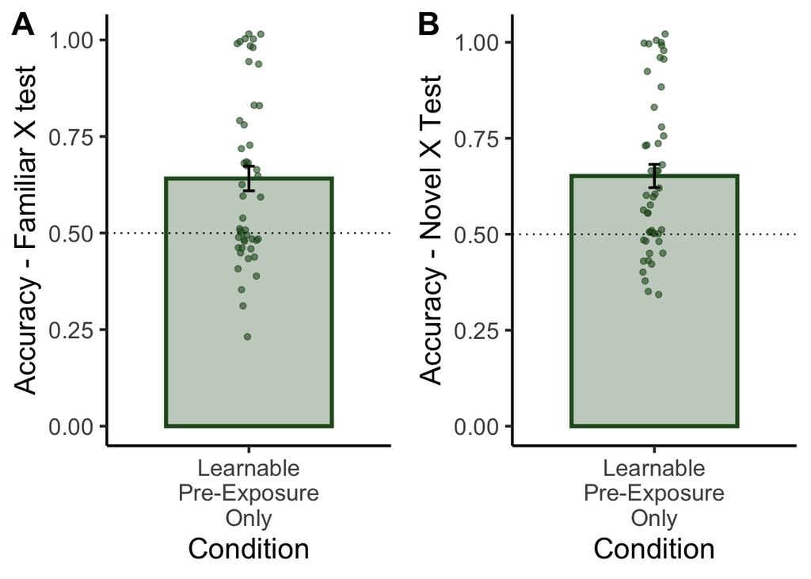

```r
#Familiar X test
p1 <- ggplot(subset(test_type_exp,testType=="familiarX"&exp=="s1"),aes(condition,accuracy,fill=condition, color=condition))+
  geom_bar(position=position_dodge(.9), stat="identity", size=1.2,alpha=0.3, width=0.7)+
  geom_jitter(data=subset(subj_testType,testType=="familiarX"&exp=="s1"),aes(y=acc), width = 0.05, alpha=0.6,shape=21)+
  geom_errorbar(aes(ymin=accuracy-se,ymax=accuracy+se),color="black",position=position_dodge(.9),width=0.05, size=0.8)+
  theme_classic(base_size=18)+
  geom_hline(yintercept=0.5, linetype="dotted")+
  scale_x_discrete(name="Condition",
                   breaks=c("Learnable Pre-Exposure Only"),
                   labels=c("Learnable\nPre-Exposure\nOnly"))+
  scale_fill_manual(values=c("#265725"))+
  scale_color_manual(values=c("#265725"))+
  theme(legend.position="none")+
  ylab("Accuracy - Familiar X test")+
  xlab("Condition")

#Novel X
p2 <- ggplot(subset(test_type_exp,testType=="novelX"&exp=="s1"),aes(condition,accuracy,fill=condition, color=condition))+
  geom_bar(position=position_dodge(.9), stat="identity", size=1.2,alpha=0.3, width=0.7)+
  geom_jitter(data=subset(subj_testType,testType=="novelX"&exp=="s1"),aes(y=acc), width = 0.05, alpha=0.6,shape=21)+
  geom_errorbar(aes(ymin=accuracy-se,ymax=accuracy+se),color="black",position=position_dodge(.9),width=0.05, size=0.8)+
  theme_classic(base_size=18)+
  geom_hline(yintercept=0.5, linetype="dotted")+
  scale_x_discrete(name="Condition",
                   breaks=c("Learnable Pre-Exposure Only"),
                   labels=c("Learnable\nPre-Exposure\nOnly"))+
  scale_fill_manual(values=c("#265725"))+
  scale_color_manual(values=c("#265725"))+
  theme(legend.position="none")+
  ylab("Accuracy - Novel X Test")+
  xlab("Condition")
plot_grid(p1,p2, labels=c("A","B"),label_size=20)
```

#### Overall Accuracy Table

```r
overall_exp %>%
  filter(exp=="s1") %>%
  #select(-c(accuracy_ci,d_prime_ci,c_bias,c_bias_ci,c_bias_lower_ci,c_bias_upper_ci)) %>%
  formattable()
```

| exp | condition | N | accuracy | se | accuracy_ci | accuracy_lower_ci | accuracy_upper_ci | d_prime | d_prime_ci | d_prime_lower_ci | d_prime_upper_ci | c_bias | c_bias_ci | c_bias_lower_ci | c_bias_upper_ci |
| --- | --- | --- | --- | --- | --- | --- | --- | --- | --- | --- | --- | --- | --- | --- | --- |
| s1 | Learnable Pre-Exposure Only | 48 | 0.646412 | 0.02951775 | 0.05938206 | 0.58703 | 0.7057941 | 1.011995 | 0.4350744 | 0.5769206 | 1.447069 | -0.24765 | 0.1082264 | -0.3558765 | -0.1394236 |

#### Accuracy Table By Test Type

```r
test_type_exp %>%
  filter(exp=="s1") %>%
  #select(-c(accuracy_ci,d_prime_ci,c_bias,c_bias_ci,c_bias_lower_ci,c_bias_upper_ci)) %>%
  formattable()
```

| exp | condition | testType | N | accuracy | se | accuracy_ci | accuracy_lower_ci | accuracy_upper_ci | d_prime | d_prime_ci | d_prime_lower_ci | d_prime_upper_ci | c_bias | c_bias_ci | c_bias_lower_ci | c_bias_upper_ci |
| --- | --- | --- | --- | --- | --- | --- | --- | --- | --- | --- | --- | --- | --- | --- | --- | --- |
| s1 | Learnable Pre-Exposure Only | familiarX | 48 | 0.6412037 | 0.03190216 | 0.06417887 | 0.5770248 | 0.7053826 | 0.8763520 | 0.4001411 | 0.4762109 | 1.276493 | -0.3730469 | 0.1184300 | -0.4914768 | -0.254616937 |
| s1 | Learnable Pre-Exposure Only | novelX | 48 | 0.6516204 | 0.03030918 | 0.06097421 | 0.5906462 | 0.7125946 | 0.9315712 | 0.3779644 | 0.5536068 | 1.309536 | -0.1136713 | 0.1082417 | -0.2219131 | -0.005429604 |

#### Correlation

##### Correlation between Familiar X and Novel X Trials

```r
##Correlations between Familiar X and Novel X
c <- corr.test(subset(subj_accuracy_wide, exp=="s1")[,c("novelX","familiarX")])
c
```

```
## Call:corr.test(x = subset(subj_accuracy_wide, exp == "s1")[, c("novelX",
##     "familiarX")])
## Correlation matrix
##           novelX familiarX
## novelX       1.0       0.8
## familiarX    0.8       1.0
## Sample Size
## [1] 48
## Probability values (Entries above the diagonal are adjusted for multiple tests.)
##           novelX familiarX
## novelX         0         0
## familiarX      0         0
##
##  To see confidence intervals of the correlations, print with the short=FALSE option
```

```r
c$p
```

```
##                 novelX    familiarX
## novelX    0.000000e+00 8.227912e-12
## familiarX 8.227912e-12 0.000000e+00
```

#### Correlation Plot

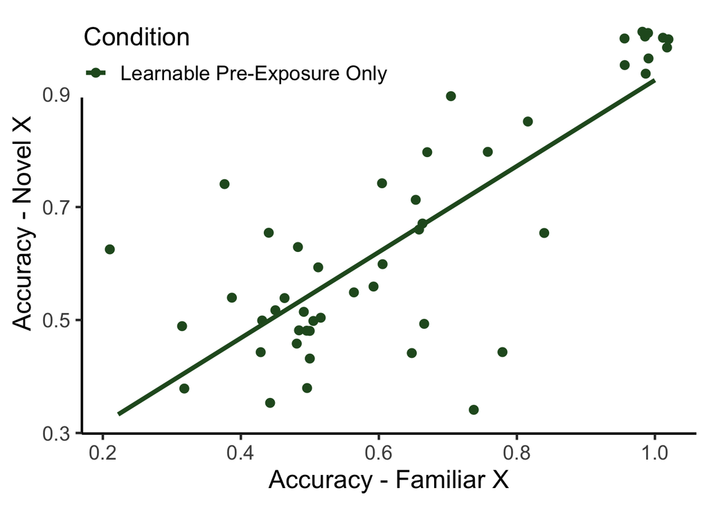

```r
ggplot(subset(subj_accuracy_wide,exp=="s1"),aes(familiarX,novelX, color=condition,linetype=condition,shape=condition))+
  geom_jitter(width=0.02,height=0.02,size=3)+
  geom_smooth(method=lm,se =F,size=1.5)+
  scale_color_manual(name="Condition",values=c("#265725"))+
  scale_linetype_manual(name="Condition",values=c(1))+
  scale_shape_manual(name="Condition",values=c(16))+
  ylab("Accuracy - Novel X")+
  xlab("Accuracy - Familiar X")+
  theme_classic(base_size=18)+
  theme(legend.position=c(0.25,0.9))
```

### Logistic Mixed-Effects Model

#### Overall

##### Final Converging Model

The final model with the maximal random effects structure that still allowed the model to converge.

```r
m <- glmer(isRight~1+(1|participantCode),data=subset(d,exp=="s1"),family=binomial,glmerControl(optimizer="bobyqa"))
summary(m)
```

```
## Generalized linear mixed model fit by maximum likelihood (Laplace
##   Approximation) [glmerMod]
##  Family: binomial  ( logit )
## Formula: isRight ~ 1 + (1 | participantCode)
##    Data: subset(d, exp == "s1")
## Control: glmerControl(optimizer = "bobyqa")
##
##      AIC      BIC   logLik deviance df.resid
##   2025.6   2036.5  -1010.8   2021.6     1726
##
## Scaled residuals:
##     Min      1Q  Median      3Q     Max
## -4.0537 -0.9745  0.2467  0.8765  1.2702
##
## Random effects:
##  Groups          Name        Variance Std.Dev.
##  participantCode (Intercept) 1.782    1.335
## Number of obs: 1728, groups:  participantCode, 48
##
## Fixed effects:
##             Estimate Std. Error z value Pr(>|z|)
## (Intercept)   0.9017     0.2065   4.367 1.26e-05 ***
## ---
## Signif. codes:  0 '***' 0.001 '**' 0.01 '*' 0.05 '.' 0.1 ' ' 1
```

```r
confint(m, method="Wald")
```

```
##                 2.5 %   97.5 %
## .sig01             NA       NA
## (Intercept) 0.4970538 1.306441
```

##### Maximal Random Effects Model

Note that this model does not converge (singular fit), thus the parameter estimates should be interpreted with caution.

```r
m <- glmer(isRight~1+(1|participantCode)+(1|stimulus),data=subset(d,exp=="s1"),family=binomial,glmerControl(optimizer="bobyqa"))
```

```
## boundary (singular) fit: see ?isSingular
```

```r
summary(m)
```

```
## Generalized linear mixed model fit by maximum likelihood (Laplace
##   Approximation) [glmerMod]
##  Family: binomial  ( logit )
## Formula: isRight ~ 1 + (1 | participantCode) + (1 | stimulus)
##    Data: subset(d, exp == "s1")
## Control: glmerControl(optimizer = "bobyqa")
##
##      AIC      BIC   logLik deviance df.resid
##   2027.6   2044.0  -1010.8   2021.6     1725
##
## Scaled residuals:
##     Min      1Q  Median      3Q     Max
## -4.0537 -0.9745  0.2467  0.8765  1.2702
##
## Random effects:
##  Groups          Name        Variance Std.Dev.
##  participantCode (Intercept) 1.782    1.335
##  stimulus        (Intercept) 0.000    0.000
## Number of obs: 1728, groups:  participantCode, 48; stimulus, 36
##
## Fixed effects:
##             Estimate Std. Error z value Pr(>|z|)
## (Intercept)   0.9017     0.2065   4.367 1.26e-05 ***
## ---
## Signif. codes:  0 '***' 0.001 '**' 0.01 '*' 0.05 '.' 0.1 ' ' 1
## convergence code: 0
## boundary (singular) fit: see ?isSingular
```

```r
confint(m, method="Wald")
```

```
##                2.5 %   97.5 %
## .sig01            NA       NA
## .sig02            NA       NA
## (Intercept) 0.497068 1.306398
```

#### Familiar X Trials

##### Final Converging Model

The final model with the maximal random effects structure that still allowed the model to converge.

```r
m <- glmer(isRight~1+(1|participantCode),data=subset(d,exp=="s1"&testType=="familiarX"),family=binomial,glmerControl(optimizer="bobyqa"))
summary(m)
```

```
## Generalized linear mixed model fit by maximum likelihood (Laplace
##   Approximation) [glmerMod]
##  Family: binomial  ( logit )
## Formula: isRight ~ 1 + (1 | participantCode)
##    Data: subset(d, exp == "s1" & testType == "familiarX")
## Control: glmerControl(optimizer = "bobyqa")
##
##      AIC      BIC   logLik deviance df.resid
##   1045.4   1054.9   -520.7   1041.4      862
##
## Scaled residuals:
##     Min      1Q  Median      3Q     Max
## -2.8641 -0.9603  0.2777  0.7782  1.5632
##
## Random effects:
##  Groups          Name        Variance Std.Dev.
##  participantCode (Intercept) 1.373    1.172
## Number of obs: 864, groups:  participantCode, 48
##
## Fixed effects:
##             Estimate Std. Error z value Pr(>|z|)
## (Intercept)   0.7916     0.1923   4.116 3.85e-05 ***
## ---
## Signif. codes:  0 '***' 0.001 '**' 0.01 '*' 0.05 '.' 0.1 ' ' 1
```

```r
confint(m, method="Wald")
```

```
##                 2.5 %   97.5 %
## .sig01             NA       NA
## (Intercept) 0.4146819 1.168537
```

##### Maximal Random Effects Model

Note that this model does not converge (singular fit), thus the parameter estimates should be interpreted with caution.

```r
m <- glmer(isRight~1+(1|participantCode)+(1|stimulus),data=subset(d,exp=="s1"&testType=="familiarX"),family=binomial,glmerControl(optimizer="bobyqa"))
```

```
## boundary (singular) fit: see ?isSingular
```

```r
summary(m)
```

```
## Generalized linear mixed model fit by maximum likelihood (Laplace
##   Approximation) [glmerMod]
##  Family: binomial  ( logit )
## Formula: isRight ~ 1 + (1 | participantCode) + (1 | stimulus)
##    Data: subset(d, exp == "s1" & testType == "familiarX")
## Control: glmerControl(optimizer = "bobyqa")
##
##      AIC      BIC   logLik deviance df.resid
##   1047.4   1061.7   -520.7   1041.4      861
##
## Scaled residuals:
##     Min      1Q  Median      3Q     Max
## -2.8640 -0.9603  0.2777  0.7782  1.5632
##
## Random effects:
##  Groups          Name        Variance Std.Dev.
##  participantCode (Intercept) 1.373    1.172
##  stimulus        (Intercept) 0.000    0.000
## Number of obs: 864, groups:  participantCode, 48; stimulus, 18
##
## Fixed effects:
##             Estimate Std. Error z value Pr(>|z|)
## (Intercept)   0.7916     0.1923   4.116 3.85e-05 ***
## ---
## Signif. codes:  0 '***' 0.001 '**' 0.01 '*' 0.05 '.' 0.1 ' ' 1
## convergence code: 0
## boundary (singular) fit: see ?isSingular
```

```r
confint(m, method="Wald")
```

```
##                 2.5 %   97.5 %
## .sig01             NA       NA
## .sig02             NA       NA
## (Intercept) 0.4146746 1.168538
```

#### Novel X Trials

##### Final Converging Model

The final model with the maximal random effects structure that still allowed the model to converge.

```r
m <- glmer(isRight~1+(1|participantCode),data=subset(d,exp=="s1"&testType=="novelX"),family=binomial,glmerControl(optimizer="bobyqa"))
summary(m)
```

```
## Generalized linear mixed model fit by maximum likelihood (Laplace
##   Approximation) [glmerMod]
##  Family: binomial  ( logit )
## Formula: isRight ~ 1 + (1 | participantCode)
##    Data: subset(d, exp == "s1" & testType == "novelX")
## Control: glmerControl(optimizer = "bobyqa")
##
##      AIC      BIC   logLik deviance df.resid
##   1048.9   1058.4   -522.4   1044.9      862
##
## Scaled residuals:
##     Min      1Q  Median      3Q     Max
## -2.7843 -0.9724  0.3592  0.7737  1.2429
##
## Random effects:
##  Groups          Name        Variance Std.Dev.
##  participantCode (Intercept) 1.166    1.08
## Number of obs: 864, groups:  participantCode, 48
##
## Fixed effects:
##             Estimate Std. Error z value Pr(>|z|)
## (Intercept)   0.8163     0.1797   4.543 5.56e-06 ***
## ---
## Signif. codes:  0 '***' 0.001 '**' 0.01 '*' 0.05 '.' 0.1 ' ' 1
```

```r
confint(m, method="Wald")
```

```
##                 2.5 %   97.5 %
## .sig01             NA       NA
## (Intercept) 0.4640702 1.168449
```

##### Maximal Random Effects Model

Note that this model does not converge (singular fit), thus the parameter estimates should be interpreted with caution.

```r
m <- glmer(isRight~1+(1|participantCode)+(1|stimulus),data=subset(d,exp=="s1"&testType=="novelX"),family=binomial,glmerControl(optimizer="bobyqa"))
```

```
## boundary (singular) fit: see ?isSingular
```

```r
summary(m)
```

```
## Generalized linear mixed model fit by maximum likelihood (Laplace
##   Approximation) [glmerMod]
##  Family: binomial  ( logit )
## Formula: isRight ~ 1 + (1 | participantCode) + (1 | stimulus)
##    Data: subset(d, exp == "s1" & testType == "novelX")
## Control: glmerControl(optimizer = "bobyqa")
##
##      AIC      BIC   logLik deviance df.resid
##   1050.9   1065.1   -522.4   1044.9      861
##
## Scaled residuals:
##     Min      1Q  Median      3Q     Max
## -2.7843 -0.9724  0.3592  0.7737  1.2429
##
## Random effects:
##  Groups          Name        Variance  Std.Dev.
##  participantCode (Intercept) 1.166e+00 1.080e+00
##  stimulus        (Intercept) 1.257e-76 1.121e-38
## Number of obs: 864, groups:  participantCode, 48; stimulus, 18
##
## Fixed effects:
##             Estimate Std. Error z value Pr(>|z|)
## (Intercept)   0.8163     0.1797   4.543 5.56e-06 ***
## ---
## Signif. codes:  0 '***' 0.001 '**' 0.01 '*' 0.05 '.' 0.1 ' ' 1
## convergence code: 0
## boundary (singular) fit: see ?isSingular
```

```r
confint(m, method="Wald")
```

```
##                 2.5 %   97.5 %
## .sig01             NA       NA
## .sig02             NA       NA
## (Intercept) 0.4640675 1.168448
```

#### Comparison to No Pre-Exposure condition from Experiment 2

##### All Test Trials

###### Final Converging Model

The final model with the maximal random effects structure that still allowed the model to converge.

```r
#compare to No Pre-Exposure condition from Experiment 2
#recode condition
d$conditionC <- ifelse(d$condition=="Learnable Pre-Exposure Only",0.5,
                       ifelse(d$condition=="No Pre-Exposure",-0.5,NA))
m <- glmer(isRight~conditionC+(1|participantCode),data=subset(d,exp=="s1"|(exp=="exp2"&condition=="No Pre-Exposure")),family=binomial,glmerControl(optimizer="bobyqa"))
summary(m)
```

```
## Generalized linear mixed model fit by maximum likelihood (Laplace
##   Approximation) [glmerMod]
##  Family: binomial  ( logit )
## Formula: isRight ~ conditionC + (1 | participantCode)
##    Data:
## subset(d, exp == "s1" | (exp == "exp2" & condition == "No Pre-Exposure"))
## Control: glmerControl(optimizer = "bobyqa")
##
##      AIC      BIC   logLik deviance df.resid
##   6036.3   6055.6  -3015.1   6030.3     4641
##
## Scaled residuals:
##     Min      1Q  Median      3Q     Max
## -3.0895 -1.0167  0.3237  0.8949  1.3116
##
## Random effects:
##  Groups          Name        Variance Std.Dev.
##  participantCode (Intercept) 0.6149   0.7841
## Number of obs: 4644, groups:  participantCode, 129
##
## Fixed effects:
##             Estimate Std. Error z value Pr(>|z|)
## (Intercept)  0.49378    0.08032   6.147 7.87e-10 ***
## conditionC   0.55590    0.15961   3.483 0.000496 ***
## ---
## Signif. codes:  0 '***' 0.001 '**' 0.01 '*' 0.05 '.' 0.1 ' ' 1
##
## Correlation of Fixed Effects:
##            (Intr)
## conditionC 0.287
```

```r
confint(m, method="Wald")
```

```
##                 2.5 %    97.5 %
## .sig01             NA        NA
## (Intercept) 0.3363528 0.6512145
## conditionC  0.2430805 0.8687295
```

###### Maximal Random Effects Model

Note that this model does not converge (singular fit), thus the parameter estimates should be interpreted with caution.

```r
m <- glmer(isRight~conditionC+(1|participantCode)+(1+conditionC|stimulus),data=subset(d,exp=="s1"|(exp=="exp2"&condition=="No Pre-Exposure")),family=binomial,glmerControl(optimizer="bobyqa"))
```

```
## boundary (singular) fit: see ?isSingular
```

```r
summary(m)
```

```
## Generalized linear mixed model fit by maximum likelihood (Laplace
##   Approximation) [glmerMod]
##  Family: binomial  ( logit )
## Formula: isRight ~ conditionC + (1 | participantCode) + (1 + conditionC |
##     stimulus)
##    Data:
## subset(d, exp == "s1" | (exp == "exp2" & condition == "No Pre-Exposure"))
## Control: glmerControl(optimizer = "bobyqa")
##
##      AIC      BIC   logLik deviance df.resid
##   6042.3   6080.9  -3015.1   6030.3     4638
##
## Scaled residuals:
##     Min      1Q  Median      3Q     Max
## -3.0895 -1.0167  0.3237  0.8949  1.3116
##
## Random effects:
##  Groups          Name        Variance  Std.Dev.  Corr
##  participantCode (Intercept) 6.149e-01 7.841e-01
##  stimulus        (Intercept) 0.000e+00 0.000e+00
##                  conditionC  5.426e-13 7.366e-07  NaN
## Number of obs: 4644, groups:  participantCode, 129; stimulus, 72
##
## Fixed effects:
##             Estimate Std. Error z value Pr(>|z|)
## (Intercept)  0.49378    0.08033   6.147 7.89e-10 ***
## conditionC   0.55590    0.15961   3.483 0.000496 ***
## ---
## Signif. codes:  0 '***' 0.001 '**' 0.01 '*' 0.05 '.' 0.1 ' ' 1
##
## Correlation of Fixed Effects:
##            (Intr)
## conditionC 0.287
## convergence code: 0
## boundary (singular) fit: see ?isSingular
```

```r
confint(m, method="Wald")[5:6,]
```

```
##                 2.5 %    97.5 %
## (Intercept) 0.3363456 0.6512215
## conditionC  0.2430712 0.8687369
```

##### Familiar X Test Trials

###### Final Converging Model

The final model with the maximal random effects structure that still allowed the model to converge.

```r
#compare to No Pre-Exposure condition from Experiment 2
m <- glmer(isRight~conditionC+(1|participantCode),data=subset(d,(exp=="s1"|(exp=="exp2"&condition=="No Pre-Exposure"))&testType=="familiarX"),family=binomial,glmerControl(optimizer="bobyqa"))
summary(m)
```

```
## Generalized linear mixed model fit by maximum likelihood (Laplace
##   Approximation) [glmerMod]
##  Family: binomial  ( logit )
## Formula: isRight ~ conditionC + (1 | participantCode)
##    Data:
## subset(d, (exp == "s1" | (exp == "exp2" & condition == "No Pre-Exposure")) &
##     testType == "familiarX")
## Control: glmerControl(optimizer = "bobyqa")
##
##      AIC      BIC   logLik deviance df.resid
##   3072.1   3089.3  -1533.0   3066.1     2319
##
## Scaled residuals:
##     Min      1Q  Median      3Q     Max
## -2.2045 -1.0370  0.4558  0.8925  1.2954
##
## Random effects:
##  Groups          Name        Variance Std.Dev.
##  participantCode (Intercept) 0.4379   0.6617
## Number of obs: 2322, groups:  participantCode, 129
##
## Fixed effects:
##             Estimate Std. Error z value Pr(>|z|)
## (Intercept)  0.44492    0.07719   5.764  8.2e-09 ***
## conditionC   0.45795    0.15337   2.986  0.00283 **
## ---
## Signif. codes:  0 '***' 0.001 '**' 0.01 '*' 0.05 '.' 0.1 ' ' 1
##
## Correlation of Fixed Effects:
##            (Intr)
## conditionC 0.289
```

```r
confint(m, method="Wald")
```

```
##                 2.5 %    97.5 %
## .sig01             NA        NA
## (Intercept) 0.2936397 0.5962060
## conditionC  0.1573446 0.7585483
```

###### Maximal Random Effects Model

Note that this model does not converge (singular fit), thus the parameter estimates should be interpreted with caution.

```r
m <- glmer(isRight~conditionC+(1|participantCode)+(1+conditionC|stimulus),data=subset(d,(exp=="s1"|(exp=="exp2"&condition=="No Pre-Exposure"))&testType=="familiarX"),family=binomial,glmerControl(optimizer="bobyqa"))
```

```
## boundary (singular) fit: see ?isSingular
```

```r
summary(m)
```

```
## Generalized linear mixed model fit by maximum likelihood (Laplace
##   Approximation) [glmerMod]
##  Family: binomial  ( logit )
## Formula: isRight ~ conditionC + (1 | participantCode) + (1 + conditionC |
##     stimulus)
##    Data:
## subset(d, (exp == "s1" | (exp == "exp2" & condition == "No Pre-Exposure")) &
##     testType == "familiarX")
## Control: glmerControl(optimizer = "bobyqa")
##
##      AIC      BIC   logLik deviance df.resid
##   3078.1   3112.6  -1533.0   3066.1     2316
##
## Scaled residuals:
##     Min      1Q  Median      3Q     Max
## -2.2045 -1.0370  0.4558  0.8925  1.2954
##
## Random effects:
##  Groups          Name        Variance  Std.Dev.  Corr
##  participantCode (Intercept) 4.379e-01 6.617e-01
##  stimulus        (Intercept) 0.000e+00 0.000e+00
##                  conditionC  5.111e-14 2.261e-07  NaN
## Number of obs: 2322, groups:  participantCode, 129; stimulus, 36
##
## Fixed effects:
##             Estimate Std. Error z value Pr(>|z|)
## (Intercept)  0.44492    0.07719   5.764  8.2e-09 ***
## conditionC   0.45795    0.15337   2.986  0.00283 **
## ---
## Signif. codes:  0 '***' 0.001 '**' 0.01 '*' 0.05 '.' 0.1 ' ' 1
##
## Correlation of Fixed Effects:
##            (Intr)
## conditionC 0.289
## convergence code: 0
## boundary (singular) fit: see ?isSingular
```

```r
confint(m, method="Wald")[5:6,]
```

```
##                 2.5 %    97.5 %
## (Intercept) 0.2936385 0.5962072
## conditionC  0.1573528 0.7585392
```

##### Novel X Trials

###### Final Converging Model

The final model with the maximal random effects structure that still allowed the model to converge.

```r
#compare to No Pre-Exposure condition from Experiment 2
m <- glmer(isRight~conditionC+(1|participantCode),data=subset(d,(exp=="s1"|(exp=="exp2"&condition=="No Pre-Exposure"))&testType=="novelX"),family=binomial,glmerControl(optimizer="bobyqa"))
summary(m)
```

```
## Generalized linear mixed model fit by maximum likelihood (Laplace
##   Approximation) [glmerMod]
##  Family: binomial  ( logit )
## Formula: isRight ~ conditionC + (1 | participantCode)
##    Data:
## subset(d, (exp == "s1" | (exp == "exp2" & condition == "No Pre-Exposure")) &
##     testType == "novelX")
## Control: glmerControl(optimizer = "bobyqa")
##
##      AIC      BIC   logLik deviance df.resid
##   3077.6   3094.9  -1535.8   3071.6     2319
##
## Scaled residuals:
##     Min      1Q  Median      3Q     Max
## -2.1515 -1.0345  0.4827  0.9013  1.2818
##
## Random effects:
##  Groups          Name        Variance Std.Dev.
##  participantCode (Intercept) 0.3747   0.6122
## Number of obs: 2322, groups:  participantCode, 129
##
## Fixed effects:
##             Estimate Std. Error z value Pr(>|z|)
## (Intercept)  0.44545    0.07344   6.066 1.31e-09 ***
## conditionC   0.52673    0.14605   3.606  0.00031 ***
## ---
## Signif. codes:  0 '***' 0.001 '**' 0.01 '*' 0.05 '.' 0.1 ' ' 1
##
## Correlation of Fixed Effects:
##            (Intr)
## conditionC 0.292
```

```r
confint(m, method="Wald")
```

```
##                 2.5 %    97.5 %
## .sig01             NA        NA
## (Intercept) 0.3015137 0.5893828
## conditionC  0.2404672 0.8129891
```

###### Maximal Random Effects Model

Note that this model does not converge (singular fit), thus the parameter estimates should be interpreted with caution.

```r
m <- glmer(isRight~conditionC+(1|participantCode)+(1+conditionC|stimulus),data=subset(d,(exp=="s1"|(exp=="exp2"&condition=="No Pre-Exposure"))&testType=="novelX"),family=binomial,glmerControl(optimizer="bobyqa"))
```

```
## boundary (singular) fit: see ?isSingular
```

```r
summary(m)
```

```
## Generalized linear mixed model fit by maximum likelihood (Laplace
##   Approximation) [glmerMod]
##  Family: binomial  ( logit )
## Formula: isRight ~ conditionC + (1 | participantCode) + (1 + conditionC |
##     stimulus)
##    Data:
## subset(d, (exp == "s1" | (exp == "exp2" & condition == "No Pre-Exposure")) &
##     testType == "novelX")
## Control: glmerControl(optimizer = "bobyqa")
##
##      AIC      BIC   logLik deviance df.resid
##   3083.6   3118.1  -1535.8   3071.6     2316
##
## Scaled residuals:
##     Min      1Q  Median      3Q     Max
## -2.1515 -1.0345  0.4827  0.9013  1.2818
##
## Random effects:
##  Groups          Name        Variance  Std.Dev.  Corr
##  participantCode (Intercept) 3.747e-01 6.122e-01
##  stimulus        (Intercept) 0.000e+00 0.000e+00
##                  conditionC  9.772e-14 3.126e-07  NaN
## Number of obs: 2322, groups:  participantCode, 129; stimulus, 36
##
## Fixed effects:
##             Estimate Std. Error z value Pr(>|z|)
## (Intercept)  0.44545    0.07344   6.066 1.31e-09 ***
## conditionC   0.52673    0.14606   3.606 0.000311 ***
## ---
## Signif. codes:  0 '***' 0.001 '**' 0.01 '*' 0.05 '.' 0.1 ' ' 1
##
## Correlation of Fixed Effects:
##            (Intr)
## conditionC 0.292
## convergence code: 0
## boundary (singular) fit: see ?isSingular
```

```r
confint(m, method="Wald")[5:6,]
```

```
##                 2.5 %    97.5 %
## (Intercept) 0.3015126 0.5893824
## conditionC  0.2404509 0.8130027
```

### Signal Detection Analysis

#### Overall

```r
##all data
m <- lm(dprime~1,data=subset(subj_overall,exp=="s1"))
summary(m)
```

```
##
## Call:
## lm(formula = dprime ~ 1, data = subset(subj_overall, exp == "s1"))
##
## Residuals:
##     Min      1Q  Median      3Q     Max
## -1.7249 -1.0120 -0.6694  0.5681  2.8170
##
## Coefficients:
##             Estimate Std. Error t value Pr(>|t|)
## (Intercept)   1.0120     0.2163   4.679 2.47e-05 ***
## ---
## Signif. codes:  0 '***' 0.001 '**' 0.01 '*' 0.05 '.' 0.1 ' ' 1
##
## Residual standard error: 1.498 on 47 degrees of freedom
```

#### Familiar X Trials

```r
m <- lm(dprime~1,data=subset(subj_testType,exp=="s1"&testType=="familiarX"))
summary(m)
```

```
##
## Call:
## lm(formula = dprime ~ 1, data = subset(subj_testType, exp ==
##     "s1" & testType == "familiarX"))
##
## Residuals:
##     Min      1Q  Median      3Q     Max
## -2.5277 -0.8763 -0.2514  0.8585  2.3101
##
## Coefficients:
##             Estimate Std. Error t value Pr(>|t|)
## (Intercept)   0.8764     0.1989   4.406 6.06e-05 ***
## ---
## Signif. codes:  0 '***' 0.001 '**' 0.01 '*' 0.05 '.' 0.1 ' ' 1
##
## Residual standard error: 1.378 on 47 degrees of freedom
```

#### Novel X Trials

```r
m <- lm(dprime~1,data=subset(subj_testType,exp=="s1"&testType=="novelX"))
summary(m)
```

```
##
## Call:
## lm(formula = dprime ~ 1, data = subset(subj_testType, exp ==
##     "s1" & testType == "novelX"))
##
## Residuals:
##     Min      1Q  Median      3Q     Max
## -1.8360 -0.9316 -0.3611  0.7118  2.2549
##
## Coefficients:
##             Estimate Std. Error t value Pr(>|t|)
## (Intercept)   0.9316     0.1879   4.958 9.68e-06 ***
## ---
## Signif. codes:  0 '***' 0.001 '**' 0.01 '*' 0.05 '.' 0.1 ' ' 1
##
## Residual standard error: 1.302 on 47 degrees of freedom
```

#### Comparison to No Pre-Exposure condition from Experiment 2

##### Overall

```r
#recode condition
subj_overall$conditionC <- ifelse(subj_overall$condition=="Learnable Pre-Exposure Only",0.5,
                       ifelse(subj_overall$condition=="No Pre-Exposure",-0.5,NA))
m <- lm(dprime~conditionC,data=subset(subj_overall,exp=="s1"|(exp=="exp2"&condition=="No Pre-Exposure")))
summary(m)
```

```
##
## Call:
## lm(formula = dprime ~ conditionC, data = subset(subj_overall,
##     exp == "s1" | (exp == "exp2" & condition == "No Pre-Exposure")))
##
## Residuals:
##     Min      1Q  Median      3Q     Max
## -1.7249 -0.6257 -0.2917  0.1580  3.5373
##
## Coefficients:
##             Estimate Std. Error t value Pr(>|t|)
## (Intercept)   0.6519     0.1054   6.183 7.93e-09 ***
## conditionC    0.7203     0.2109   3.416 0.000854 ***
## ---
## Signif. codes:  0 '***' 0.001 '**' 0.01 '*' 0.05 '.' 0.1 ' ' 1
##
## Residual standard error: 1.158 on 127 degrees of freedom
## Multiple R-squared:  0.08414,    Adjusted R-squared:  0.07693
## F-statistic: 11.67 on 1 and 127 DF,  p-value: 0.0008544
```

##### Familiar X Trials

```r
#recode condition
subj_testType$conditionC <- ifelse(subj_testType$condition=="Learnable Pre-Exposure Only",0.5,
                       ifelse(subj_testType$condition=="No Pre-Exposure",-0.5,NA))

m <- lm(dprime~conditionC,data=subset(subj_testType,(exp=="s1"|(exp=="exp2"&condition=="No Pre-Exposure"))&testType=="familiarX"))
summary(m)
```

```
##
## Call:
## lm(formula = dprime ~ conditionC, data = subset(subj_testType,
##     (exp == "s1" | (exp == "exp2" & condition == "No Pre-Exposure")) &
##         testType == "familiarX"))
##
## Residuals:
##     Min      1Q  Median      3Q     Max
## -2.5277 -0.7554 -0.2995  0.4840  2.8869
##
## Coefficients:
##             Estimate Std. Error t value Pr(>|t|)
## (Intercept)   0.5879     0.1002   5.868 3.61e-08 ***
## conditionC    0.5768     0.2004   2.879  0.00469 **
## ---
## Signif. codes:  0 '***' 0.001 '**' 0.01 '*' 0.05 '.' 0.1 ' ' 1
##
## Residual standard error: 1.1 on 127 degrees of freedom
## Multiple R-squared:  0.06125,    Adjusted R-squared:  0.05386
## F-statistic: 8.286 on 1 and 127 DF,  p-value: 0.004688
```

##### Novel X Trials

```r
m <- lm(dprime~conditionC,data=subset(subj_testType,(exp=="s1"|(exp=="exp2"&condition=="No Pre-Exposure"))&testType=="novelX"))
summary(m)
```

```
##
## Call:
## lm(formula = dprime ~ conditionC, data = subset(subj_testType,
##     (exp == "s1" | (exp == "exp2" & condition == "No Pre-Exposure")) &
##         testType == "novelX"))
##
## Residuals:
##     Min      1Q  Median      3Q     Max
## -1.8360 -0.6405 -0.2467  0.3238  2.9398
##
## Coefficients:
##             Estimate Std. Error t value Pr(>|t|)
## (Intercept)   0.5891     0.0947   6.221 6.59e-09 ***
## conditionC    0.6849     0.1894   3.616  0.00043 ***
## ---
## Signif. codes:  0 '***' 0.001 '**' 0.01 '*' 0.05 '.' 0.1 ' ' 1
##
## Residual standard error: 1.04 on 127 degrees of freedom
## Multiple R-squared:  0.09336,    Adjusted R-squared:  0.08622
## F-statistic: 13.08 on 1 and 127 DF,  p-value: 0.0004296
```